# Behind the Paycheck: Inside DC's Public Workforce

### A Compensation, Tenure, and Structure Analysis of the District's 35,000+ Public Employees

**Author:** Sule  
**Course:** MATH 014 — Introduction to Data Science  
**Term:** Spring 2026 · Howard University

## 1 · Introduction

The District of Columbia government employs more than forty thousand people across roughly ninety agencies — a workforce larger than many Fortune 500 companies and one whose payroll is funded entirely by public dollars. The **DC Public Employee Salary** dataset, published openly by DC Open Data, makes that payroll inspectable: every full-time employee, their job title, the agency that employs them, their pay grade, their hire date, and their annual compensation rate.

This project investigates three questions about that workforce:

1. **How does compensation vary across DC's agencies, and which agencies have the highest median pay?**
2. **Does tenure predict pay — and does that relationship behave differently across appointment categories** (Career Service, Educational Service, Management Supervisory Service, etc.)?
3. **Where is pay dispersion (inequality) most extreme inside individual agencies?**

The dataset is analytically compelling because it sits at the intersection of three things this course has emphasized: *real-world messiness* (mixed casing, sentinel values, parseable date strings), *mixed variable types* (categorical agency codes, ordinal grades, continuous compensation, datetime hire dates), and *narrative-rich groupings* that reward both univariate and multivariate exploration.

## 2 · Importing Libraries

```python
import warnings
warnings.filterwarnings("ignore")

import numpy as np
import pandas as pd
import matplotlib.pyplot as plt
import seaborn as sns
import plotly.express as px

# Display settings
pd.set_option("display.max_columns", 30)
pd.set_option("display.width", 140)
sns.set_theme(style="whitegrid", context="notebook")
PALETTE = ["#0B5394", "#3D85C6", "#76A5AF", "#E69138", "#CC4125", "#674EA7"]
sns.set_palette(PALETTE)
plt.rcParams["figure.dpi"] = 100
```

## 3 · Data Loading

The raw CSV ships from DC Open Data with nine columns covering identity, role, agency, grade, compensation, hire date, and appointment type. We read it without any assumptions about types so we can inspect them directly.

```python
raw = pd.read_csv("dc_salary_raw.csv")
print(f"Rows: {len(raw):,}   Columns: {raw.shape[1]}")
raw.head()
```

```
Rows: 40,611   Columns: 9
```

|  | FIRST_NAME | LAST_NAME | JOBTITLE | DESCRSHORT | GRADE | COMPRATE | HIREDATE_STRING | GVT_TYPE_OF_APPT | OBJECTID |
| --- | --- | --- | --- | --- | --- | --- | --- | --- | --- |
| 0 | Natasha | Boley | Compliance Specialist | DBH | 13 | 123873.00 | 2004/10/18 | CS - Reg | 1 |
| 1 | Korlu | Wolobah-Kuyon | PSYCHIATRIC NURSE | DBH | 09 | 115907.00 | 2020/08/17 | CS - Reg | 2 |
| 2 | Hadizat | Elayo-Ross | SUPERVISORY PSYCHIATRIC NURSE | DBH | 13 | 122500.00 | 2023/08/14 | MSS - Reg | 3 |
| 3 | Gary | Evans | Climate Control Maint Mechanic | DBH | 11 | 41.73 | 1985/08/27 | CS - Reg | 4 |
| 4 | Jemia | Gross | Special Police Officer | DBH | 08 | 75787.00 | 2016/11/14 | CS - Reg | 5 |

## 4 · Data Understanding

Before any cleaning we audit *what* we have: types, missingness, cardinality, and the shape of the numeric variable that will drive most of the analysis.

```python
raw.dtypes
```

```
FIRST_NAME              str
LAST_NAME               str
JOBTITLE                str
DESCRSHORT              str
GRADE                   str
COMPRATE            float64
HIREDATE_STRING         str
GVT_TYPE_OF_APPT        str
OBJECTID              int64
dtype: object
```

```python
raw.isna().sum()
```

```
FIRST_NAME           0
LAST_NAME            0
JOBTITLE             0
DESCRSHORT           0
GRADE               40
COMPRATE             0
HIREDATE_STRING      0
GVT_TYPE_OF_APPT     0
OBJECTID             0
dtype: int64
```

```python
raw.nunique().sort_values(ascending=False)
```

```
OBJECTID            40611
LAST_NAME           15110
FIRST_NAME          12930
HIREDATE_STRING      4914
COMPRATE             4360
JOBTITLE             3698
DESCRSHORT             88
GRADE                  68
GVT_TYPE_OF_APPT       18
dtype: int64
```

```python
raw["COMPRATE"].describe().round(2)
```

```
count     40611.00
mean      89087.76
std       47453.79
min           0.03
25%       66130.00
50%       93234.00
75%      119643.13
max      390232.00
Name: COMPRATE, dtype: float64
```

**Initial read of the raw data:**

- **40,611 rows** of employees, each with a unique `OBJECTID`, so there are no exact duplicates.
- `GRADE` has 40 missing values out of ~40K rows — small enough to handle individually rather than drop.
- `COMPRATE` has a minimum value of **$0.03** and a maximum of **$390,232**. The lower end is clearly a data-entry artifact (no DC employee earns three cents annually) — we'll handle it with a salary floor during cleaning.
- `JOBTITLE` is high-cardinality (3,698 distinct titles) — useful for spot-checks but not directly groupable.
- `DESCRSHORT` (88 unique values) is the agency code — the right granularity for cross-group analysis.
- `GVT_TYPE_OF_APPT` decomposes naturally into a *category* (CS, Ed, MSS, ExS, LS, Exe, Acting) and a *status* (Reg, Term, Temp). We'll engineer that split in the cleaning step.

## 5 · Data Cleaning

Cleaning is documented step-by-step below. Each transformation is justified inline; we re-check shape and missingness after the major operations.

```python
df = raw.copy()

# 5a. Strip whitespace from all string columns
for c in df.select_dtypes(include="object").columns:
    df[c] = df[c].astype(str).str.strip()

# 5b. JOBTITLE arrives in mixed casing ("Compliance Specialist" vs "PSYCHIATRIC NURSE")
#     — title case standardizes display without loss of information.
df["JOBTITLE"] = df["JOBTITLE"].str.title()

# 5c. Parse HIREDATE_STRING ('YYYY/MM/DD') into a real datetime object
df["HIRE_DATE"] = pd.to_datetime(df["HIREDATE_STRING"], format="%Y/%m/%d", errors="coerce")
print(f"HIRE_DATE failed parses: {df['HIRE_DATE'].isna().sum()}")
df.head(3)
```

```
HIRE_DATE failed parses: 0
```

|  | FIRST_NAME | LAST_NAME | JOBTITLE | DESCRSHORT | GRADE | COMPRATE | HIREDATE_STRING | GVT_TYPE_OF_APPT | OBJECTID | HIRE_DATE |
| --- | --- | --- | --- | --- | --- | --- | --- | --- | --- | --- |
| 0 | Natasha | Boley | Compliance Specialist | DBH | 13 | 123873.0 | 2004/10/18 | CS - Reg | 1 | 2004-10-18 |
| 1 | Korlu | Wolobah-Kuyon | Psychiatric Nurse | DBH | 09 | 115907.0 | 2020/08/17 | CS - Reg | 2 | 2020-08-17 |
| 2 | Hadizat | Elayo-Ross | Supervisory Psychiatric Nurse | DBH | 13 | 122500.0 | 2023/08/14 | MSS - Reg | 3 | 2023-08-14 |

```python
# 5d. Salary floor: drop rows with COMPRATE < $10,000.
# The raw minimum is $0.03 and other suspiciously-low values cluster below $5K.
# A $10K floor preserves part-time / seasonal positions while removing data-entry errors.
salary_floor = 10_000
n_dropped = (df["COMPRATE"] < salary_floor).sum()
print(f"Dropping {n_dropped} rows below ${salary_floor:,}")
df = df[df["COMPRATE"] >= salary_floor].copy()
```

```
Dropping 4984 rows below $10,000
```

```python
# 5e. Fill missing GRADE with 'UNK' rather than dropping
#     (those 40 rows still carry information about pay/agency/tenure)
df["GRADE"] = df["GRADE"].fillna("UNK").replace({"nan": "UNK"})

# 5f. Engineer features
ANALYSIS_DATE = pd.Timestamp("2026-04-26")
df["TENURE_YEARS"] = ((ANALYSIS_DATE - df["HIRE_DATE"]).dt.days / 365.25).round(2)
df["HIRE_YEAR"] = df["HIRE_DATE"].dt.year
df["HIRE_DECADE"] = (df["HIRE_YEAR"] // 10 * 10).astype("Int64").astype(str) + "s"

# Decompose 'CS - Reg' into category + status for richer grouping
appt = df["GVT_TYPE_OF_APPT"].str.split(" - ", n=1, expand=True)
df["APPT_CATEGORY"] = appt[0].str.strip()
df["APPT_STATUS"] = appt[1].fillna("Other").str.strip()

# 5g. Drop the now-redundant raw columns
df = df.drop(columns=["OBJECTID", "HIREDATE_STRING"])

print(f"Cleaned shape: {df.shape}")
df.head(3)
```

```
Cleaned shape: (35627, 13)
```

|  | FIRST_NAME | LAST_NAME | JOBTITLE | DESCRSHORT | GRADE | COMPRATE | GVT_TYPE_OF_APPT | HIRE_DATE | TENURE_YEARS | HIRE_YEAR | HIRE_DECADE | APPT_CATEGORY | APPT_STATUS |
| --- | --- | --- | --- | --- | --- | --- | --- | --- | --- | --- | --- | --- | --- |
| 0 | Natasha | Boley | Compliance Specialist | DBH | 13 | 123873.0 | CS - Reg | 2004-10-18 | 21.52 | 2004 | 2000s | CS | Reg |
| 1 | Korlu | Wolobah-Kuyon | Psychiatric Nurse | DBH | 09 | 115907.0 | CS - Reg | 2020-08-17 | 5.69 | 2020 | 2020s | CS | Reg |
| 2 | Hadizat | Elayo-Ross | Supervisory Psychiatric Nurse | DBH | 13 | 122500.0 | MSS - Reg | 2023-08-14 | 2.70 | 2023 | 2020s | MSS | Reg |

```python
# 5h. Verify post-clean state: no missingness in critical columns, types correct
df.isna().sum()
```

```
FIRST_NAME          0
LAST_NAME           0
JOBTITLE            0
DESCRSHORT          0
GRADE               0
COMPRATE            0
GVT_TYPE_OF_APPT    0
HIRE_DATE           0
TENURE_YEARS        0
HIRE_YEAR           0
HIRE_DECADE         0
APPT_CATEGORY       0
APPT_STATUS         0
dtype: int64
```

```python
df.dtypes
```

```
FIRST_NAME                     str
LAST_NAME                      str
JOBTITLE                       str
DESCRSHORT                     str
GRADE                          str
COMPRATE                   float64
GVT_TYPE_OF_APPT               str
HIRE_DATE           datetime64[us]
TENURE_YEARS               float64
HIRE_YEAR                    int32
HIRE_DECADE                    str
APPT_CATEGORY                  str
APPT_STATUS                    str
dtype: object
```

```python
# Persist the cleaned dataset (Canvas deliverable)
df.to_csv("sule_final_project.csv", index=False)
print("Saved cleaned dataset → sule_final_project.csv")
```

```
Saved cleaned dataset → sule_final_project.csv
```

## 6 · Exploratory Data Analysis

With clean data in hand we build a quantitative picture of compensation, agency size, and appointment structure before any plotting.

```python
# Compensation percentiles
df["COMPRATE"].quantile([0.10, 0.25, 0.50, 0.75, 0.90, 0.95, 0.99]).round(0)
```

```
0.10     59736.0
0.25     75433.0
0.50    100313.0
0.75    123873.0
0.90    140000.0
0.95    160000.0
0.99    206802.0
Name: COMPRATE, dtype: float64
```

The compensation distribution is *fairly tight* by federal-payroll standards: 80% of employees earn between roughly $60K and $140K, with a long right tail extending to nearly $400K for senior executives.

```python
# Appointment-category breakdown — median pay and headcount
(df.groupby("APPT_CATEGORY")
    .agg(headcount=("COMPRATE", "size"),
         median_pay=("COMPRATE", "median"),
         mean_pay=("COMPRATE", "mean"))
    .sort_values("median_pay", ascending=False)
    .round(0))
```

| APPT_CATEGORY | headcount | median_pay | mean_pay |
| --- | --- | --- | --- |
| Exe | 68 | 226596.0 | 205241.0 |
| LS | 671 | 154877.0 | 154601.0 |
| MSS | 2552 | 125000.0 | 127746.0 |
| ExS | 599 | 120824.0 | 128488.0 |
| Acting | 9 | 111419.0 | 102457.0 |
| Ed | 10914 | 103780.0 | 99714.0 |
| CS | 20814 | 94139.0 | 96466.0 |

The appointment category is the single strongest predictor of pay in this dataset: **Executive (Exe)** roles cluster around $225K medians; **Career Service (CS)** — the largest category at ~20K employees — sits near $95K.

```python
# Top 15 agencies by employee count, with their median pay
top15 = df["DESCRSHORT"].value_counts().head(15).index
(df[df["DESCRSHORT"].isin(top15)]
   .groupby("DESCRSHORT")
   .agg(employees=("COMPRATE", "size"),
        median_pay=("COMPRATE", "median"),
        mean_tenure=("TENURE_YEARS", "mean"))
   .sort_values("employees", ascending=False)
   .round(1))
```

| DESCRSHORT | employees | median_pay | mean_tenure |
| --- | --- | --- | --- |
| DCPS | 10133 | 105071.0 | 9.5 |
| MPD | 4095 | 110595.0 | 12.6 |
| FEMS | 2335 | 92113.0 | 13.2 |
| OCFO | 1386 | 118558.0 | 14.4 |
| DHS | 1178 | 89329.0 | 13.9 |
| DBH | 1166 | 101290.0 | 13.9 |
| DDOT | 1135 | 83500.0 | 12.6 |
| DOC | 1066 | 73954.0 | 11.7 |
| UDC | 838 | 81206.2 | 11.8 |
| DOH | 801 | 101290.0 | 9.4 |
| DOES | 718 | 88300.0 | 11.4 |
| OAG | 674 | 118558.0 | 10.6 |
| CFSA | 654 | 107046.0 | 15.4 |
| DPR | 580 | 68116.0 | 14.1 |
| DCPL | 544 | 70919.0 | 13.0 |

**DC Public Schools (DCPS)** dominates the workforce at over 10,000 employees — roughly *three out of every ten* employees in the cleaned dataset. The Metropolitan Police Department (MPD) is the second-largest at ~4,100, and Fire & EMS (FEMS) third at ~2,300.

## 7 · Data Visualization and Interpretation

### 7.1 · Univariate — Distribution of Annual Compensation

**Intent:** Establish the global shape of the response variable before we slice it. We overlay the median and mean to see how skewed the tail is.

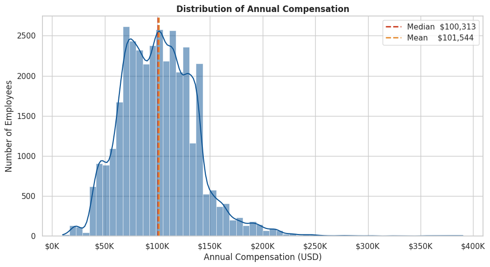

```python
fig, ax = plt.subplots(figsize=(10, 5.5))
sns.histplot(df["COMPRATE"], bins=60, kde=True, color=PALETTE[0],
             ax=ax, edgecolor="white", linewidth=0.4)
median_pay = df["COMPRATE"].median()
mean_pay = df["COMPRATE"].mean()
ax.axvline(median_pay, color=PALETTE[4], ls="--", lw=2, label=f"Median  ${median_pay:,.0f}")
ax.axvline(mean_pay, color=PALETTE[3], ls="--", lw=2, label=f"Mean    ${mean_pay:,.0f}")
ax.set_title("Distribution of Annual Compensation", fontweight="bold")
ax.set_xlabel("Annual Compensation (USD)")
ax.set_ylabel("Number of Employees")
ax.xaxis.set_major_formatter(plt.matplotlib.ticker.FuncFormatter(lambda x, _: f"${x/1000:.0f}K"))
ax.legend()
plt.tight_layout()
plt.show()
```

**Interpretation.** The distribution is bimodal-ish, with a primary mode near $70K–$100K (the bulk of Career Service employees) and a secondary shoulder near $120K–$140K. The mean ($101.5K) and median ($100.3K) are nearly identical, which is unusual for a salary distribution and tells us that the upper tail — though it stretches to nearly $400K — contains too few employees to drag the mean meaningfully above the median. This is the empirical fingerprint of a *capped* compensation system with grade ceilings, not a winner-take-all market.

### 7.2 · Univariate — Largest Agencies by Headcount

**Intent:** Identify which agencies dominate the workforce so that downstream group-level analyses focus on agencies large enough to support stable estimates.

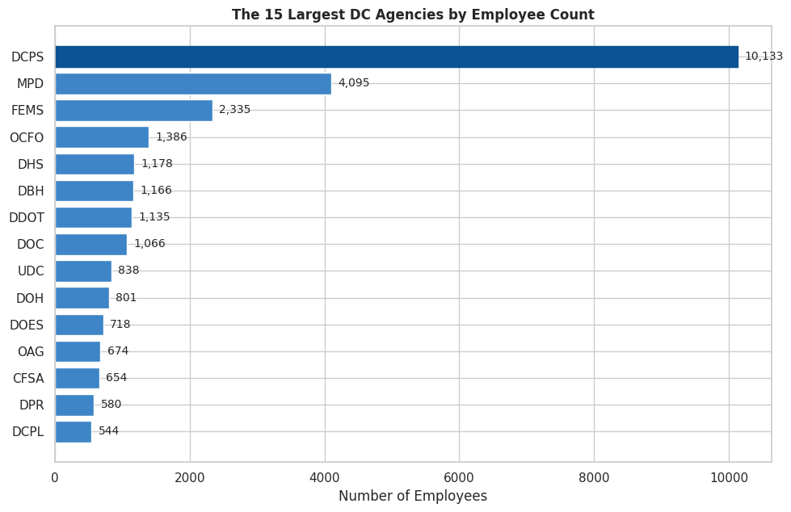

```python
top15 = df["DESCRSHORT"].value_counts().head(15)
fig, ax = plt.subplots(figsize=(10, 6.5))
bars = ax.barh(top15.index[::-1], top15.values[::-1], color=PALETTE[1], edgecolor="white")
bars[-1].set_color(PALETTE[0])
ax.set_title("The 15 Largest DC Agencies by Employee Count", fontweight="bold")
ax.set_xlabel("Number of Employees")
for bar, v in zip(bars, top15.values[::-1]):
    ax.text(bar.get_width() + 100, bar.get_y() + bar.get_height()/2,
            f"{v:,}", va="center", fontsize=10)
plt.tight_layout()
plt.show()
```

**Interpretation.** A handful of agencies absorb most of the workforce. **DCPS alone is ~2.5× the size of the next-largest agency (MPD).** Together, the top three (DCPS, MPD, FEMS) account for over 16,500 of the 35,627 cleaned employees — nearly half. This concentration matters for every subsequent comparison: medians and dispersion ratios for these three agencies are statistically robust, while smaller agencies will sometimes show noisy effects.

### 7.3 · Bivariate — Compensation by Appointment Category

**Intent:** Compare the seven appointment categories side-by-side to see which structural employment categories command the highest pay and which carry the most internal variability.

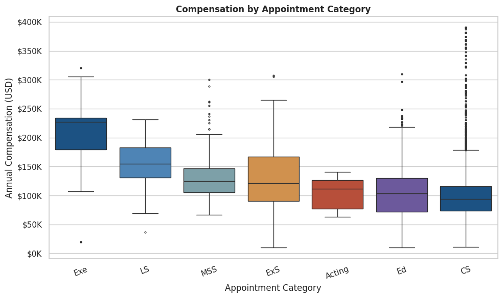

```python
order = (df.groupby("APPT_CATEGORY")["COMPRATE"].median()
           .sort_values(ascending=False).index.tolist())
fig, ax = plt.subplots(figsize=(10, 6))
sns.boxplot(data=df, x="APPT_CATEGORY", y="COMPRATE",
            order=order, palette=PALETTE, fliersize=2, ax=ax)
ax.set_title("Compensation by Appointment Category", fontweight="bold")
ax.set_xlabel("Appointment Category")
ax.set_ylabel("Annual Compensation (USD)")
ax.yaxis.set_major_formatter(plt.matplotlib.ticker.FuncFormatter(lambda x, _: f"${x/1000:.0f}K"))
plt.xticks(rotation=20)
plt.tight_layout()
plt.show()
```

### 7.4 · Bivariate — Tenure vs. Compensation

**Intent:** Test whether longer tenure systematically predicts higher pay. We use a downsampled scatter (8,000 points) plus a regression line plus the Pearson correlation, which together give us both a visual sense of dispersion and a single-number summary.

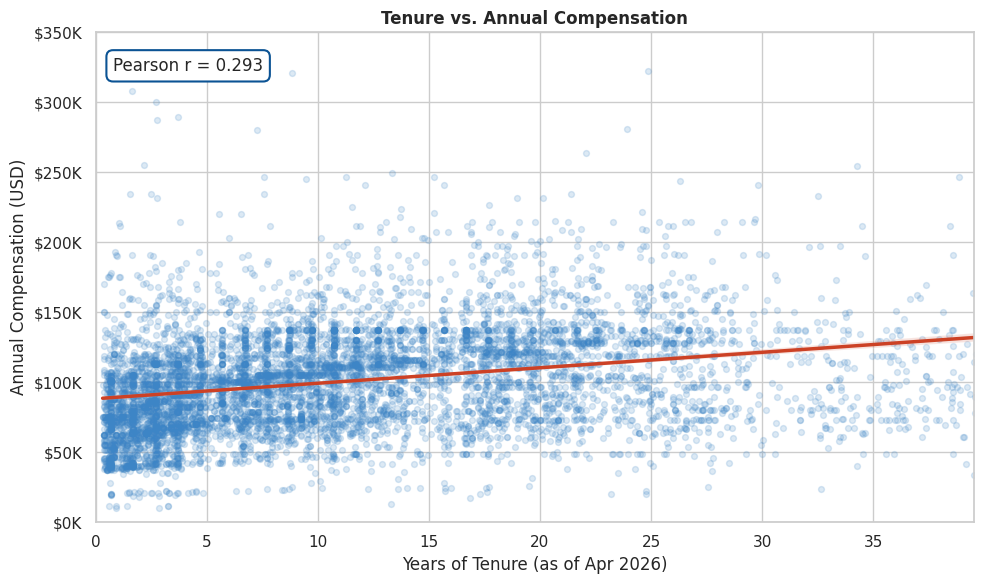

```python
sample = df.sample(min(8000, len(df)), random_state=42)
fig, ax = plt.subplots(figsize=(10, 6))
sns.regplot(data=sample, x="TENURE_YEARS", y="COMPRATE",
            scatter_kws={"alpha": 0.18, "s": 18, "color": PALETTE[1]},
            line_kws={"color": PALETTE[4], "lw": 2.5}, ax=ax)
ax.set_title("Tenure vs. Annual Compensation", fontweight="bold")
ax.set_xlabel("Years of Tenure (as of Apr 2026)")
ax.set_ylabel("Annual Compensation (USD)")
ax.set_ylim(0, 350_000)
ax.set_xlim(0, df["TENURE_YEARS"].quantile(0.99))
ax.yaxis.set_major_formatter(plt.matplotlib.ticker.FuncFormatter(lambda x, _: f"${x/1000:.0f}K"))
r = df[["TENURE_YEARS", "COMPRATE"]].corr().iloc[0, 1]
ax.text(0.02, 0.95, f"Pearson r = {r:.3f}", transform=ax.transAxes,
        fontsize=12, va="top",
        bbox=dict(boxstyle="round,pad=0.4", fc="white", ec=PALETTE[0], lw=1.5))
plt.tight_layout()
plt.show()
```

**Interpretation.** Pay rises with tenure, but the relationship is *modest*: Pearson *r* = 0.293, which means tenure explains only about 8.6% of the variance in compensation (*r²*). The visual confirms this — at every tenure level there is enormous spread, suggesting tenure is *one* lever among many (grade, agency, appointment type all matter independently). The horizontal banding visible in the cloud is the imprint of the GS-style grade structure: employees at the same grade earn very similar amounts regardless of which year they were hired.

### 7.5 · Multivariate — Heatmap of Median Pay (Agency × Appointment)

**Intent:** Cross-tabulate the two strongest grouping variables to see *where* in the agency × appointment matrix the highest pay concentrates.

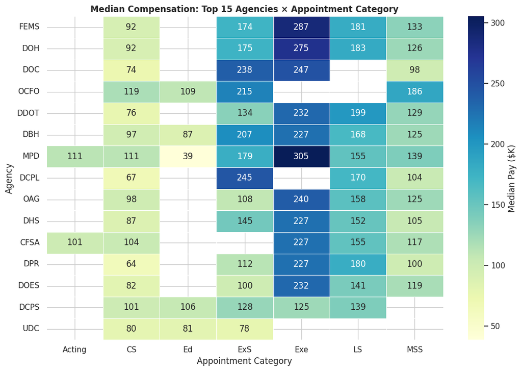

```python
top_agencies_15 = df["DESCRSHORT"].value_counts().head(15).index.tolist()
heat = (df[df["DESCRSHORT"].isin(top_agencies_15)]
        .groupby(["DESCRSHORT", "APPT_CATEGORY"])["COMPRATE"]
        .median().unstack())
heat = heat.loc[heat.mean(axis=1).sort_values(ascending=False).index]

fig, ax = plt.subplots(figsize=(11, 7.5))
sns.heatmap(heat / 1000, annot=True, fmt=".0f", cmap="YlGnBu",
            cbar_kws={"label": "Median Pay ($K)"},
            linewidths=0.5, linecolor="white", ax=ax)
ax.set_title("Median Compensation: Top 15 Agencies × Appointment Category",
             fontweight="bold")
ax.set_xlabel("Appointment Category")
ax.set_ylabel("Agency")
plt.tight_layout()
plt.show()
```

**Interpretation.** Three patterns jump out. First, *agency baseline matters*: the OCFO (Office of the Chief Financial Officer) Career Service medians ($119K) are higher than CS medians at almost every other agency, reflecting the technical/financial skill premium. Second, *executive bands are wide across agencies* — MPD's Exe-tier pay tops $300K, more than DCPS's executive pay ($125K), suggesting differing executive structures by mission. Third, the matrix has structural empty cells: not every agency uses every appointment category (UDC has no Exe column, DCPL has no Ed column), which is itself information about how each agency is organized.

### 7.6 · Multivariate — Compensation Density by Category and Status

**Intent:** Use a FacetGrid to see whether *Term* and *Temp* employees within each appointment category earn meaningfully less than their *Regular* counterparts — a question about whether appointment status creates a pay penalty independent of role.

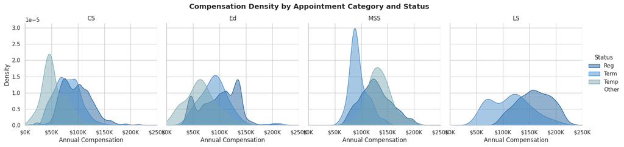

```python
top_cats = df["APPT_CATEGORY"].value_counts().head(4).index.tolist()
sub = df[df["APPT_CATEGORY"].isin(top_cats)].copy()
sub["APPT_STATUS_GROUP"] = sub["APPT_STATUS"].where(
    sub["APPT_STATUS"].isin(["Reg", "Term", "Temp"]), "Other"
)
g = sns.FacetGrid(sub, col="APPT_CATEGORY", col_order=top_cats,
                  hue="APPT_STATUS_GROUP", height=4, aspect=1.05,
                  hue_order=["Reg", "Term", "Temp", "Other"],
                  palette=PALETTE[:4])
g.map_dataframe(sns.kdeplot, x="COMPRATE", fill=True, alpha=0.45, common_norm=False)
g.add_legend(title="Status")
for ax in g.axes.flat:
    ax.xaxis.set_major_formatter(plt.matplotlib.ticker.FuncFormatter(lambda x, _: f"${x/1000:.0f}K"))
    ax.set_xlim(0, 250_000)
g.set_axis_labels("Annual Compensation", "Density")
g.set_titles(col_template="{col_name}")
g.fig.suptitle("Compensation Density by Appointment Category and Status",
               fontweight="bold", y=1.04)
plt.show()
```

### 7.7 · Interactive — Treemap of the Workforce

**Intent:** Provide an interactive overview where size encodes headcount and color encodes median pay, so the viewer can compare agencies on two dimensions at once and drill in via hover. This plot is interactive in the live notebook (HTML output).

```python
treemap_df = (df.groupby(["APPT_CATEGORY", "DESCRSHORT"])
                .agg(employees=("COMPRATE", "size"),
                     median_pay=("COMPRATE", "median"))
                .reset_index())
fig = px.treemap(
    treemap_df,
    path=[px.Constant("DC Government"), "APPT_CATEGORY", "DESCRSHORT"],
    values="employees",
    color="median_pay",
    color_continuous_scale="Viridis",
    hover_data={"median_pay": ":$,.0f", "employees": ":,"},
    title="DC Workforce — Size by Headcount, Color by Median Pay (hover to drill in)",
)
fig.update_layout(margin=dict(t=60, l=10, r=10, b=10), height=650)
fig.show()
```

[output not shown]

### 7.8 · Surprise Plot — Agency Landscape Bubble Chart

**Intent:** Encode four dimensions in a single chart — agency size (x, log-scale), median pay (y), mean tenure (bubble size), and proportion of employees on Term appointments (color) — so we can see where each agency *sits* in the broader workforce landscape.

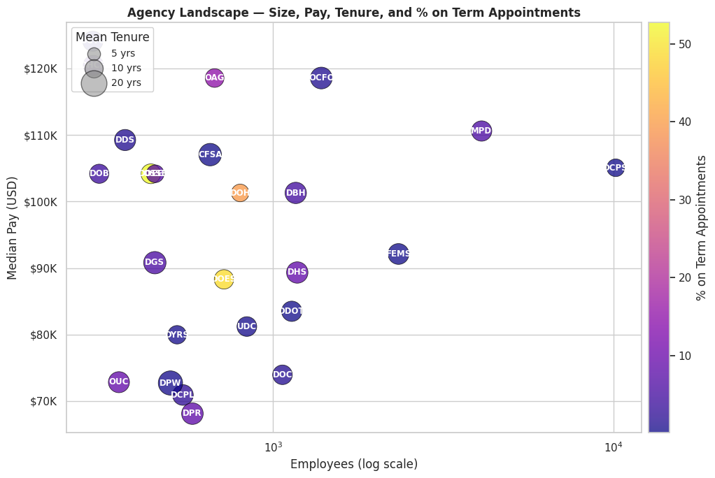

```python
top25 = df["DESCRSHORT"].value_counts().head(25).index
bubble = (df[df["DESCRSHORT"].isin(top25)]
          .groupby("DESCRSHORT")
          .agg(median_pay=("COMPRATE", "median"),
               employees=("COMPRATE", "size"),
               mean_tenure=("TENURE_YEARS", "mean"),
               pct_term=("APPT_STATUS", lambda s: (s == "Term").mean() * 100))
          .reset_index())

fig, ax = plt.subplots(figsize=(11, 7))
sc = ax.scatter(bubble["employees"], bubble["median_pay"],
                s=bubble["mean_tenure"] * 35,
                c=bubble["pct_term"], cmap="plasma",
                alpha=0.75, edgecolor="black", linewidth=0.6)
for _, row in bubble.iterrows():
    ax.annotate(row["DESCRSHORT"], (row["employees"], row["median_pay"]),
                fontsize=8.5, ha="center", va="center", color="white", weight="bold")
ax.set_xscale("log")
ax.set_xlabel("Employees (log scale)")
ax.set_ylabel("Median Pay (USD)")
ax.set_title("Agency Landscape — Size, Pay, Tenure, and % on Term Appointments",
             fontweight="bold")
ax.yaxis.set_major_formatter(plt.matplotlib.ticker.FuncFormatter(lambda x, _: f"${x/1000:.0f}K"))
cbar = plt.colorbar(sc, ax=ax, pad=0.01)
cbar.set_label("% on Term Appointments")
for tenure, label in [(5, "5 yrs"), (10, "10 yrs"), (20, "20 yrs")]:
    ax.scatter([], [], s=tenure*35, c="gray", alpha=0.5, edgecolor="black", label=label)
ax.legend(title="Mean Tenure", loc="upper left", framealpha=0.9, fontsize=10)
plt.tight_layout()
plt.show()
```

## 8 · Additional Analysis / Findings

Two analyses extend beyond the primary research questions:

1. **Pay Dispersion Index** — the P90/P10 ratio per agency, a standard inequality metric.
2. **Tenure-Controlled Pay Curve** — median pay by tenure band *within* appointment category, isolating the tenure-pay slope from the appointment-mix confound visible in §7.4.

### 8.1 · Pay Dispersion (P90 ÷ P10) by Agency

**Motivation.** A single-number measure of internal pay inequality. A ratio of 2.0× means the top 10% of an agency earns at least twice what the bottom 10% earns. We compare the top-15 agencies and benchmark against the median ratio.

```python
disp = (df[df["DESCRSHORT"].isin(top_agencies_15)]
        .groupby("DESCRSHORT")["COMPRATE"]
        .agg(p10=lambda x: x.quantile(0.10),
             p50="median",
             p90=lambda x: x.quantile(0.90))
        .assign(ratio=lambda x: x["p90"] / x["p10"])
        .sort_values("ratio", ascending=False))
disp.round(2)
```

| DESCRSHORT | p10 | p50 | p90 | ratio |
| --- | --- | --- | --- | --- |
| DDOT | 22963.00 | 83500.00 | 134126.98 | 5.84 |
| DCPS | 46175.00 | 105071.00 | 137632.00 | 2.98 |
| OCFO | 70919.00 | 118558.00 | 190823.00 | 2.69 |
| OAG | 70102.00 | 118558.00 | 187672.00 | 2.68 |
| DOH | 52909.00 | 101290.00 | 137561.00 | 2.60 |
| DPR | 45760.00 | 68116.00 | 100827.00 | 2.20 |
| DBH | 63841.50 | 101290.00 | 137561.00 | 2.15 |
| FEMS | 64105.00 | 92113.00 | 134509.00 | 2.10 |
| UDC | 62750.11 | 81206.16 | 130737.00 | 2.08 |
| DOES | 64144.00 | 88300.00 | 129630.97 | 2.02 |
| DCPL | 57925.60 | 70919.00 | 116557.10 | 2.01 |
| MPD | 75433.00 | 110595.00 | 138250.00 | 1.83 |
| DHS | 68116.00 | 89329.00 | 119916.00 | 1.76 |
| CFSA | 76431.70 | 107046.00 | 130717.00 | 1.71 |
| DOC | 56617.00 | 73954.00 | 96799.55 | 1.71 |

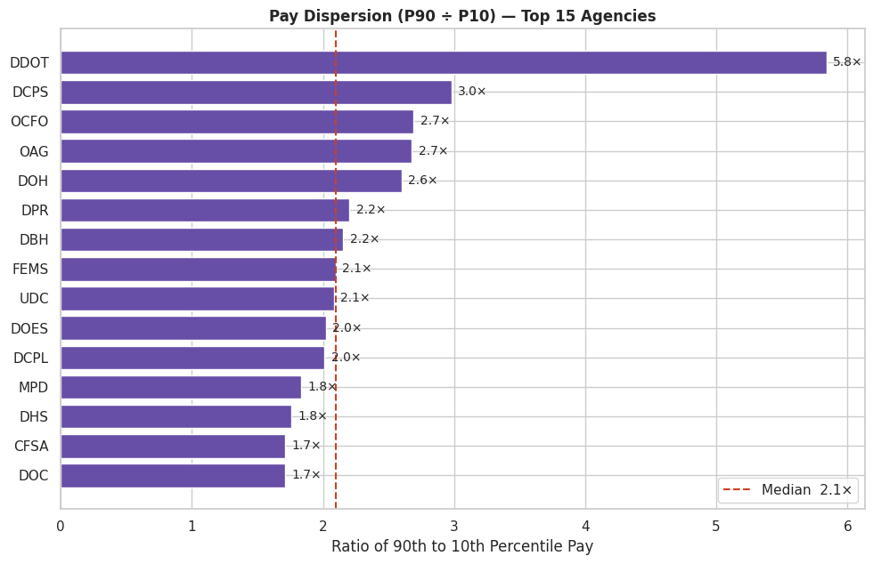

```python
fig, ax = plt.subplots(figsize=(10, 6.5))
bars = ax.barh(disp.index[::-1], disp["ratio"].values[::-1],
               color=PALETTE[5], edgecolor="white")
ax.set_title("Pay Dispersion (P90 ÷ P10) — Top 15 Agencies", fontweight="bold")
ax.set_xlabel("Ratio of 90th to 10th Percentile Pay")
for bar, v in zip(bars, disp["ratio"].values[::-1]):
    ax.text(bar.get_width() + 0.05, bar.get_y() + bar.get_height()/2,
            f"{v:.1f}×", va="center", fontsize=10)
ax.axvline(disp["ratio"].median(), color=PALETTE[4], ls="--", lw=1.5,
           label=f"Median  {disp['ratio'].median():.1f}×")
ax.legend()
plt.tight_layout()
plt.show()
```

**Interpretation.** Pay dispersion is *highest at DDOT* (5.8×, the District Department of Transportation) — a striking outlier. DDOT mixes professional engineers and senior planners with a large field crew of laborers, and the ratio captures that two-tier structure. **DCPS (3.0×) and OCFO (2.7×)** follow, both bridging large entry-level workforces with senior specialists. By contrast, **DOC (Department of Corrections, 1.7×)** and **CFSA (Child and Family Services, 1.7×)** are the most internally compressed — both are agencies where the job market is dominated by a single skilled-but-not-executive role profile.

### 8.2 · Tenure-Controlled Pay Curve by Appointment Category

```python
df["TENURE_BIN"] = pd.cut(df["TENURE_YEARS"],
                          bins=[-0.1, 2, 5, 10, 15, 20, 30, 50],
                          labels=["0-2", "2-5", "5-10", "10-15",
                                  "15-20", "20-30", "30+"])
curve = (df[df["APPT_CATEGORY"].isin(top_cats)]
         .groupby(["TENURE_BIN", "APPT_CATEGORY"], observed=True)["COMPRATE"]
         .median().reset_index())
curve.head(10)
```

|  | TENURE_BIN | APPT_CATEGORY | COMPRATE |
| --- | --- | --- | --- |
| 0 | 0-2 | CS | 71578.815 |
| 1 | 0-2 | Ed | 72655.000 |
| 2 | 0-2 | LS | 123522.000 |
| 3 | 0-2 | MSS | 124071.000 |
| 4 | 2-5 | CS | 79971.000 |
| 5 | 2-5 | Ed | 85361.000 |
| 6 | 2-5 | LS | 135017.000 |
| 7 | 2-5 | MSS | 122764.000 |
| 8 | 5-10 | CS | 92656.000 |
| 9 | 5-10 | Ed | 111403.000 |

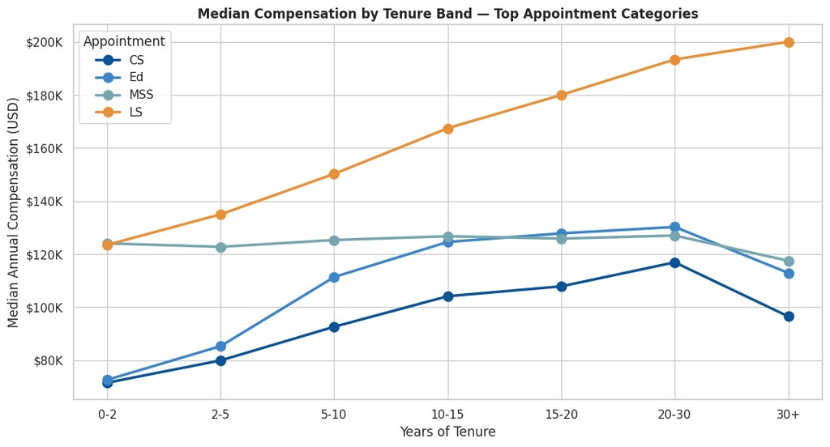

```python
fig, ax = plt.subplots(figsize=(11, 6))
for i, cat in enumerate(top_cats):
    sub_c = curve[curve["APPT_CATEGORY"] == cat]
    ax.plot(sub_c["TENURE_BIN"].astype(str), sub_c["COMPRATE"],
            marker="o", lw=2.5, markersize=9, color=PALETTE[i], label=cat)
ax.set_title("Median Compensation by Tenure Band — Top Appointment Categories",
             fontweight="bold")
ax.set_xlabel("Years of Tenure")
ax.set_ylabel("Median Annual Compensation (USD)")
ax.yaxis.set_major_formatter(plt.matplotlib.ticker.FuncFormatter(lambda x, _: f"${x/1000:.0f}K"))
ax.legend(title="Appointment", frameon=True)
plt.tight_layout()
plt.show()
```

## 9 · Insights and Conclusion

### Limitations

1. The dataset captures a single point-in-time snapshot — we cannot observe individual pay trajectories, only cross-sectional differences.
2. `COMPRATE` represents annual rate; we have no direct measure of hours actually worked. Some part-time and seasonal employees may be normalized to annual figures incorrectly.
3. The 4,984 rows we excluded with COMPRATE < $10K may contain legitimate part-time positions that we filter out alongside the data-entry errors.
4. We have no demographic information (race, gender, age), so we cannot examine pay equity along those dimensions — a major and well-documented question this dataset alone cannot answer.

### Future directions

- **Longitudinal analysis** — joining annual snapshots across multiple years to model individual pay growth.
- **Geocoded analysis** — pairing agency data with DC ward boundaries to see how public-sector compensation flows geographically through the District.
- **Skill-premium decomposition** — using the JOBTITLE field with NLP techniques to identify which competencies (cybersecurity, healthcare, law) command pay premiums above their grade.

## 10 · References

1. **DC Open Data — DC Public Employee Salary Dataset.** https://opendata.dc.gov/datasets/dc-employee-salary-information
2. **DC Department of Human Resources** — *Employee Classification and Compensation*. https://dchr.dc.gov/page/classification-and-compensation
3. **Pandas Documentation.** McKinney, W. *Data Structures for Statistical Computing in Python.* https://pandas.pydata.org/docs/
4. **Seaborn Documentation.** Waskom, M. https://seaborn.pydata.org/
5. **Plotly Express.** https://plotly.com/python/plotly-express/
6. **Matplotlib.** Hunter, J. D. *Matplotlib: A 2D Graphics Environment.* *Computing in Science & Engineering*, 2007. https://matplotlib.org/

## 11 · Acknowledgments

Thanks to **Dr. Ndoye** for the structured project framework, the in-class examples on Plotly Express and Seaborn, and the consistent guidance throughout MATH 014. Special thanks to my classmates whose questions during the in-class demos sharpened my own understanding of EDA workflows.